# GIS III - Geostatistics in R

This tutorial bases on the workshop hold by **Phaedon Kyriakidis** at the AGILE 2019 conference, June 17, Limassol, Cyprus. It was then modified by Christian Sailer and Joram Schito in order to adapt the content to the requirements of the GIS III course at ETH Zurich.

### Session Overview

#### Descriptive Statistics

#### IDW

#### Kriging

#### Assignment

# Introduction

##### Data sources:

In this course, you will be working with the *meuse* data set, which comprises data on four heavy metals measured in the top soil layer in a flood plain along the river Meuse in The Netherlands, along with a handful of covariates. The process governing heavy metal distribution appears to involve transport of polluted sediment by the river, and subsequent deposition mostly close to the river bank, and areas with low elevation.

[figure not shown]

- Structure of the Meuse river data set: [rdrr.io](https://rdrr.io/rforge/gstat/man/meuse.all.html)
- Geography of the Meuse river data set: [spatial-analyst.net](http://spatial-analyst.net/book/meusegrids)

The particular data set considered in this course consists of zinc concentrations (in ppm), as well as their natural logarithm to work with a data set with less skewed distribution. As a start, you do descriptive statistics and display the map of all zinc concentrations, the histogram of zinc concentrations and that of the logarithms of zinc concentrations. When looking at the spatial distribution of the concentration values, keep in mind that the Meuse river bank is located at the west and southwest border of the region.

##### Spatial and spatio-temportal geostatistical Modelling:

For the main part, you use the R package **gstat**, which provides basic functionality for geostatistical analysis to perform inverse distance spatial interpolation, conduct variogram estimation and modeling, spatial prediction using different types of Kriging, as well as get a glimpse of geostatistical simulation.  
You find a brief tutorial for the gstat R package as a R vignette on [vignettes gstat](https://cran.r-project.org/web/packages/gstat/vignettes/gstat.pdf) .

##### Libraries:

First, invoke the relevant libraries for this session.

```r
# Package names
packages <- c("knitr", "sp", "gstat", "dplyr", "ggfortify", "sf", "tmap")

# Install packages not yet installed
installed_packages <- packages %in% rownames(installed.packages())
if (any(installed_packages == FALSE)) {
  install.packages(packages[!installed_packages])
}

# Packages loading
invisible(lapply(packages, library, character.only = TRUE))
```

# Descriptive Statistics

Import the Meuse data set of the sp package including the shape of the river, the study area, and the grid

```r
data(meuse, package = "sp")
data(meuse.riv, package = "sp")
data(meuse.area, package = "sp")
data(meuse.grid, package = "sp")
```

[output not shown]

Show the header of the data set

```r
names(meuse)
```

```
##  [1] "x"       "y"       "cadmium" "copper"  "lead"    "zinc"    "elev"
##  [8] "dist"    "om"      "ffreq"   "soil"    "lime"    "landuse" "dist.m"
```

Display the internal structure of the meuse object

```r
str(meuse)
```

```
## 'data.frame':    155 obs. of  14 variables:
##  $ x      : num  181072 181025 181165 181298 181307 ...
##  $ y      : num  333611 333558 333537 333484 333330 ...
##  $ cadmium: num  11.7 8.6 6.5 2.6 2.8 3 3.2 2.8 2.4 1.6 ...
##  $ copper : num  85 81 68 81 48 61 31 29 37 24 ...
##  $ lead   : num  299 277 199 116 117 137 132 150 133 80 ...
##  $ zinc   : num  1022 1141 640 257 269 ...
##  $ elev   : num  7.91 6.98 7.8 7.66 7.48 ...
##  $ dist   : num  0.00136 0.01222 0.10303 0.19009 0.27709 ...
##  $ om     : num  13.6 14 13 8 8.7 7.8 9.2 9.5 10.6 6.3 ...
##  $ ffreq  : Factor w/ 3 levels "1","2","3": 1 1 1 1 1 1 1 1 1 1 ...
##  $ soil   : Factor w/ 3 levels "1","2","3": 1 1 1 2 2 2 2 1 1 2 ...
##  $ lime   : Factor w/ 2 levels "0","1": 2 2 2 1 1 1 1 1 1 1 ...
##  $ landuse: Factor w/ 15 levels "Aa","Ab","Ag",..: 4 4 4 11 4 11 4 2 2 15 ...
##  $ dist.m : num  50 30 150 270 380 470 240 120 240 420 ...
```

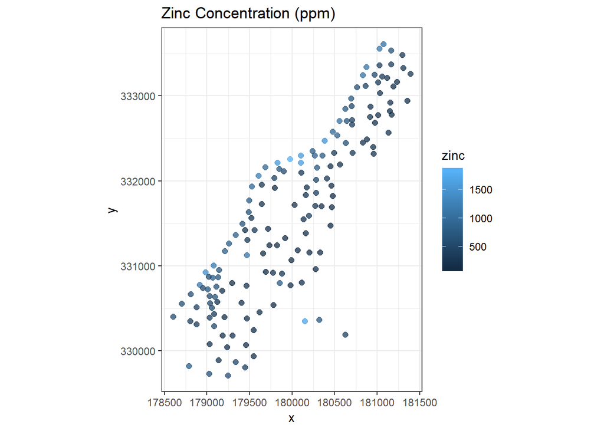

```r
ggplot(meuse, aes(x,y)) +
  geom_point(aes(color = zinc), size = 2, alpha = 3/4) +
  ggtitle("Zinc Concentration (ppm)") + coord_equal() + theme_bw()
```

Convert the Meuse data frame into an sf (simple feature) object

```r
meuse_sf = st_as_sf(as.data.frame(meuse), coords = c("x", "y"), crs = 28992, agr = "constant")
meuse_sf[1:3,]
```

```
## Simple feature collection with 3 features and 12 fields
## Attribute-geometry relationship: 12 constant, 0 aggregate, 0 identity
## geometry type:  POINT
## dimension:      XY
## bbox:           xmin: 181025 ymin: 333537 xmax: 181165 ymax: 333611
## epsg (SRID):    28992
## proj4string:    +proj=sterea +lat_0=52.15616055555555 +lon_0=5.38763888888889 +k=0.9999079 +x_0=155000 +y_0=463000 +ellps=bessel +towgs84=565.2369,50.0087,465.658,-0.406857,0.350733,-1.87035,4.0812 +units=m +no_defs
##   cadmium copper lead zinc  elev       dist   om ffreq soil lime landuse
## 1    11.7     85  299 1022 7.909 0.00135803 13.6     1    1    1      Ah
## 2     8.6     81  277 1141 6.983 0.01222430 14.0     1    1    1      Ah
## 3     6.5     68  199  640 7.800 0.10302900 13.0     1    1    1      Ah
##   dist.m              geometry
## 1     50 POINT (181072 333611)
## 2     30 POINT (181025 333558)
## 3    150 POINT (181165 333537)
```

Plot data using quick tmap

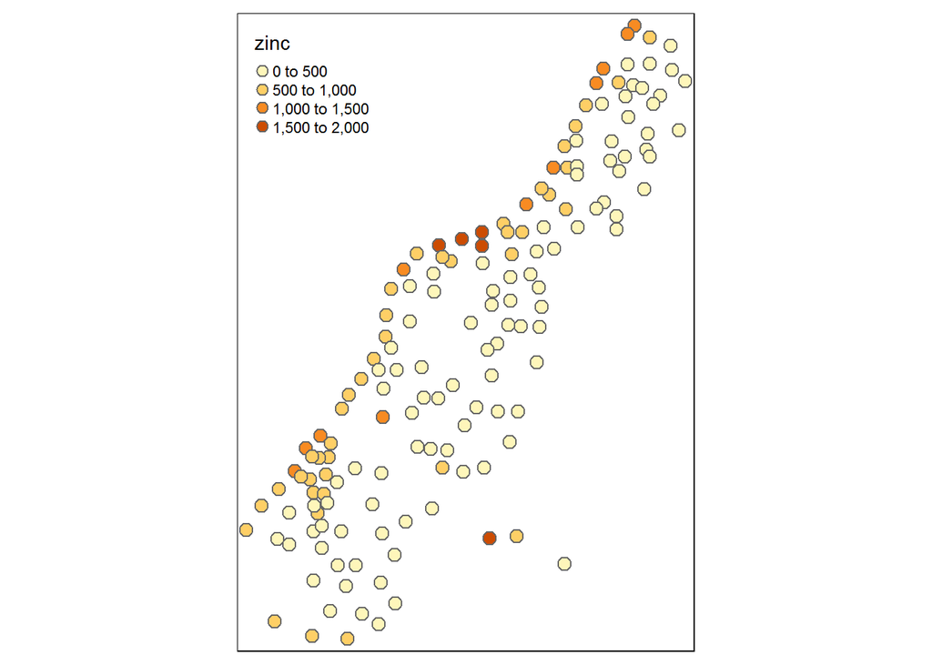

```r
qtm(meuse_sf, symbols.col = "zinc", symbols.size = 0.5)
```

Designate the coordinates in the data frame as *SpatialPointsDataFrame*

```r
coordinates(meuse) = c("x","y")
coordinates(meuse)[1:4,]
```

```
##        x      y
## 1 181072 333611
## 2 181025 333558
## 3 181165 333537
## 4 181298 333484
```

```r
class(meuse)
```

```
## [1] "SpatialPointsDataFrame"
## attr(,"package")
## [1] "sp"
```

```r
summary(meuse)
```

```
## Object of class SpatialPointsDataFrame
## Coordinates:
##      min    max
## x 178605 181390
## y 329714 333611
## Is projected: NA
## proj4string : [NA]
## Number of points: 155
## Data attributes:
##     cadmium           copper            lead            zinc
##  Min.   : 0.200   Min.   : 14.00   Min.   : 37.0   Min.   : 113.0
##  1st Qu.: 0.800   1st Qu.: 23.00   1st Qu.: 72.5   1st Qu.: 198.0
##  Median : 2.100   Median : 31.00   Median :123.0   Median : 326.0
##  Mean   : 3.246   Mean   : 40.32   Mean   :153.4   Mean   : 469.7
##  3rd Qu.: 3.850   3rd Qu.: 49.50   3rd Qu.:207.0   3rd Qu.: 674.5
##  Max.   :18.100   Max.   :128.00   Max.   :654.0   Max.   :1839.0
##
##       elev             dist               om         ffreq  soil   lime
##  Min.   : 5.180   Min.   :0.00000   Min.   : 1.000   1:84   1:97   0:111
##  1st Qu.: 7.546   1st Qu.:0.07569   1st Qu.: 5.300   2:48   2:46   1: 44
##  Median : 8.180   Median :0.21184   Median : 6.900   3:23   3:12
##  Mean   : 8.165   Mean   :0.24002   Mean   : 7.478
##  3rd Qu.: 8.955   3rd Qu.:0.36407   3rd Qu.: 9.000
##  Max.   :10.520   Max.   :0.88039   Max.   :17.000
##                                     NA's   :2
##     landuse       dist.m
##  W      :50   Min.   :  10.0
##  Ah     :39   1st Qu.:  80.0
##  Am     :22   Median : 270.0
##  Fw     :10   Mean   : 290.3
##  Ab     : 8   3rd Qu.: 450.0
##  (Other):25   Max.   :1000.0
##  NA's   : 1
```

Display the data using spplot: Display the attribute "zinc" as z value

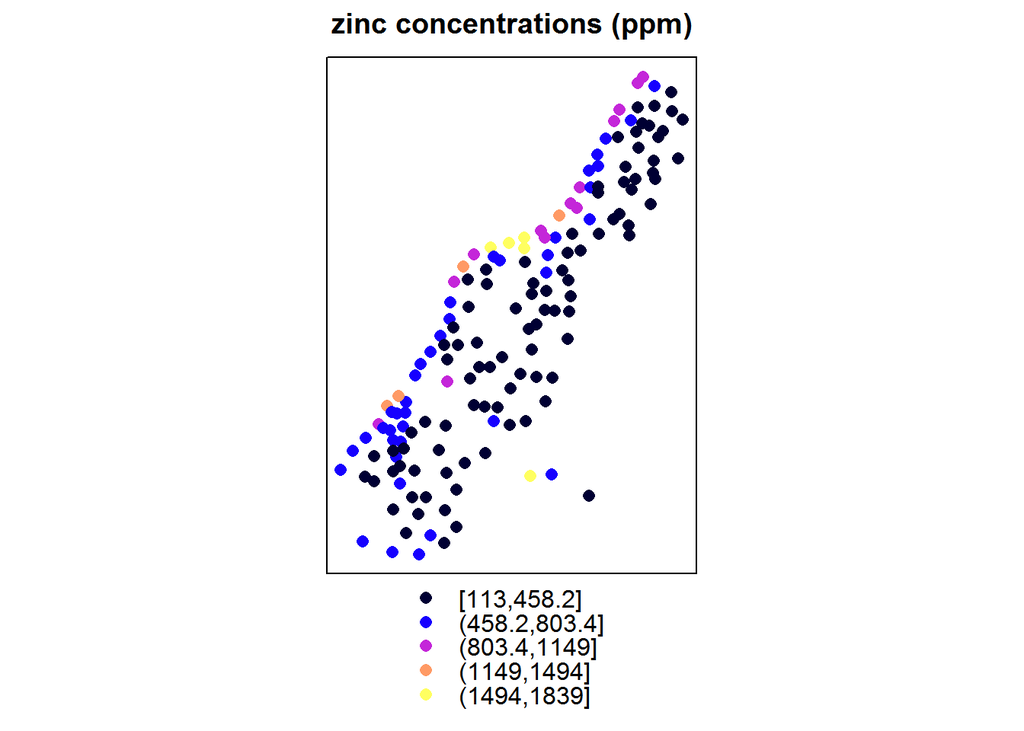

```r
spplot(meuse, zcol="zinc", main = "zinc concentrations (ppm)")
```

Create a spatial polygon object from the the river data

```r
meuse.sr = SpatialPolygons(list(Polygons(list(Polygon(meuse.riv)), "meuse.riv")))
```

Now, put the legend to the right, set own class breaks, and add the shape of the river

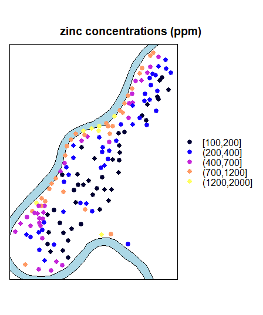

```r
spplot(meuse, zcol="zinc", col.regions=bpy.colors(),  main = "zinc concentrations (ppm)",
       cuts = c(100,200,400,700,1200,2000), key.space = "right",
       sp.layout= list("sp.polygons", meuse.sr, fill = "lightblue")
)
```

Histogram of zinc concentration data

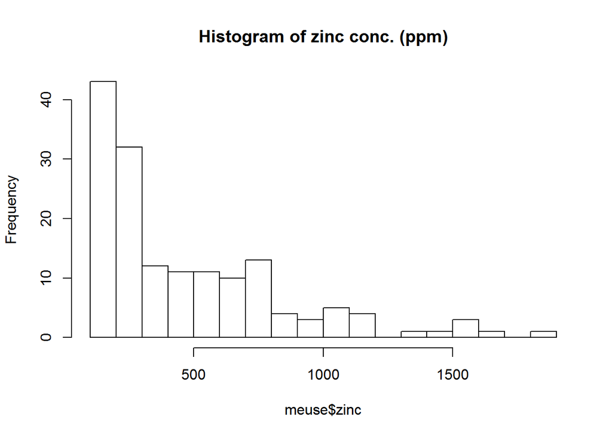

```r
hist(meuse$zinc, breaks = 15, main = "Histogram of zinc conc. (ppm)")
```

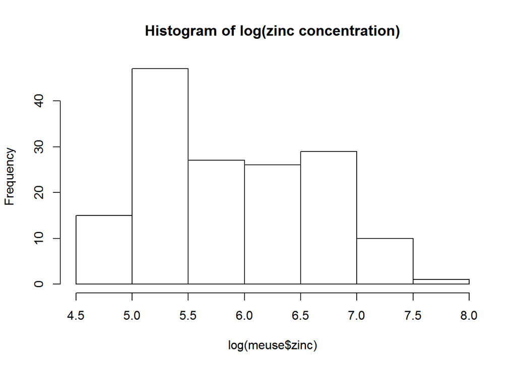

```r
hist(log(meuse$zinc), breaks = "scott", main = "Histogram of log(zinc concentration)")
```

The Meuse data set provides a grid for the interpolation, prediction, and simulation. First, check its structure.

```r
data(meuse.grid)
summary(meuse.grid)
```

```
##        x                y              part.a           part.b
##  Min.   :178460   Min.   :329620   Min.   :0.0000   Min.   :0.0000
##  1st Qu.:179420   1st Qu.:330460   1st Qu.:0.0000   1st Qu.:0.0000
##  Median :179980   Median :331220   Median :0.0000   Median :1.0000
##  Mean   :179985   Mean   :331348   Mean   :0.3986   Mean   :0.6014
##  3rd Qu.:180580   3rd Qu.:332140   3rd Qu.:1.0000   3rd Qu.:1.0000
##  Max.   :181540   Max.   :333740   Max.   :1.0000   Max.   :1.0000
##       dist        soil     ffreq
##  Min.   :0.0000   1:1665   1: 779
##  1st Qu.:0.1193   2:1084   2:1335
##  Median :0.2715   3: 354   3: 989
##  Mean   :0.2971
##  3rd Qu.:0.4402
##  Max.   :0.9926
```

```r
class(meuse.grid)
```

```
## [1] "data.frame"
```

```r
str(meuse.grid)
```

```
## 'data.frame':    3103 obs. of  7 variables:
##  $ x     : num  181180 181140 181180 181220 181100 ...
##  $ y     : num  333740 333700 333700 333700 333660 ...
##  $ part.a: num  1 1 1 1 1 1 1 1 1 1 ...
##  $ part.b: num  0 0 0 0 0 0 0 0 0 0 ...
##  $ dist  : num  0 0 0.0122 0.0435 0 ...
##  $ soil  : Factor w/ 3 levels "1","2","3": 1 1 1 1 1 1 1 1 1 1 ...
##  $ ffreq : Factor w/ 3 levels "1","2","3": 1 1 1 1 1 1 1 1 1 1 ...
```

Display the prediction grid and overlay the sample data locations

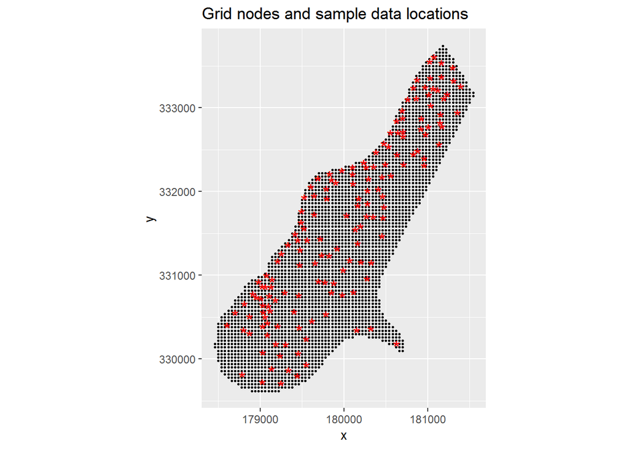

```r
p1 <- ggplot(data = as.data.frame(meuse.grid), aes(x,y)) + geom_point(size = 0.5) +
      coord_equal() + ggtitle("Grid nodes and sample data locations")
p1 +  geom_point(data = as.data.frame(meuse), aes(x,y), shape = "*", size = 5, color = "red")
```

Turn the prediction grid into a *SpatialPointsDataFrame*

```r
coordinates(meuse.grid) <- c("x","y")
class(meuse.grid)
```

```
## [1] "SpatialPointsDataFrame"
## attr(,"package")
## [1] "sp"
```

```r
str(meuse.grid)
```

```
## Formal class 'SpatialPointsDataFrame' [package "sp"] with 5 slots
##   ..@ data       :'data.frame':  3103 obs. of  5 variables:
##   .. ..$ part.a: num [1:3103] 1 1 1 1 1 1 1 1 1 1 ...
##   .. ..$ part.b: num [1:3103] 0 0 0 0 0 0 0 0 0 0 ...
##   .. ..$ dist  : num [1:3103] 0 0 0.0122 0.0435 0 ...
##   .. ..$ soil  : Factor w/ 3 levels "1","2","3": 1 1 1 1 1 1 1 1 1 1 ...
##   .. ..$ ffreq : Factor w/ 3 levels "1","2","3": 1 1 1 1 1 1 1 1 1 1 ...
##   ..@ coords.nrs : int [1:2] 1 2
##   ..@ coords     : num [1:3103, 1:2] 181180 181140 181180 181220 181100 ...
##   .. ..- attr(*, "dimnames")=List of 2
##   .. .. ..$ : chr [1:3103] "1" "2" "3" "4" ...
##   .. .. ..$ : chr [1:2] "x" "y"
##   ..@ bbox       : num [1:2, 1:2] 178460 329620 181540 333740
##   .. ..- attr(*, "dimnames")=List of 2
##   .. .. ..$ : chr [1:2] "x" "y"
##   .. .. ..$ : chr [1:2] "min" "max"
##   ..@ proj4string:Formal class 'CRS' [package "sp"] with 1 slot
##   .. .. ..@ projargs: chr NA
```

Turn the *SpatialPointsDataFrame* into a *SpatialPixelsDataFrame*

```r
gridded(meuse.grid) = TRUE
class(meuse.grid)
```

```
## [1] "SpatialPixelsDataFrame"
## attr(,"package")
## [1] "sp"
```

Display the distance to the river with ggplot

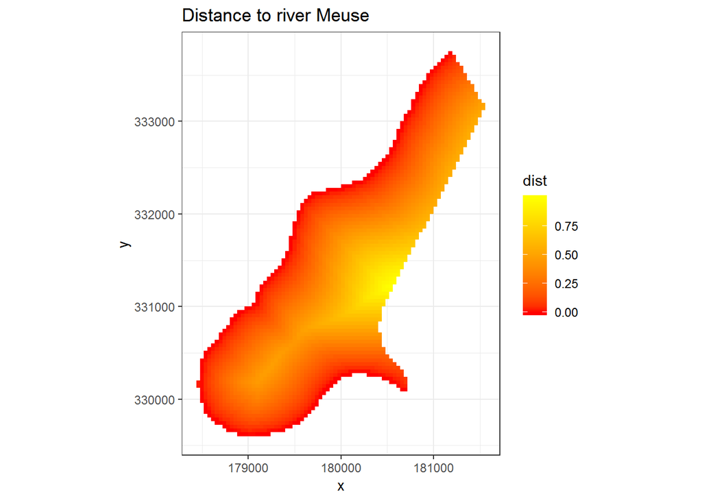

```r
ggplot(as.data.frame(meuse.grid), aes(x, y)) + geom_tile(aes(fill=dist)) +
scale_fill_gradient(low = "red", high="yellow") + coord_equal() + theme_bw() +
ggtitle("Distance to river Meuse")
```

Display the distance to the river with spplot

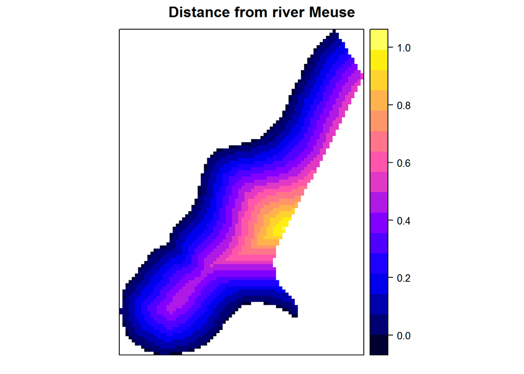

```r
spplot(meuse.grid["dist"], main="Distance from river Meuse")
```

# Inverse Distance Weighting spatial interpolation

Interpolation is the spatial operation whereby $N$ sample data values $\{z({\bf u})_i, i=1,\ldots,N\}$ measured at $N$ locations $\{{\bf u}_i, i=1,\ldots,N\}$ are used to furnish a prediction $\hat{z}({\bf u}_0)$ for the unknown attribute value $z({\bf u}_0)$ at a prediction location with coordinate vector ${\bf u}_0$. In general, linear interpolation algorithms amount to furnish $N$ weights $\{w_i({\bf u}_0), i=1,\ldots,N\}$ for interpolation at location ${\bf u}_0$, where $w_i({\bf u}_0)$ denotes the weight assinged to the $i$-th location ${\bf u}_i$. Once the $N$ weights are determined, the interpolated value is given as:

$$\hat{z}({\bf u}_0) = \sum_{i=1}^N w_i({\bf u}_0) z({\bf u}_i) \; \; \; \mbox{or simply} \; \; \; \hat{z}_0 = \sum_{i=1}^N w_{0i} z_i$$

Interpolation algorithms differ in the way the $N$ data are weighted to furnish the interpolated value $\hat{z}_0$.

Inverse distance weighting (IDW) spatial interpolation is a widely used deterministic interpolation algorithm, where the interpolation weight $w_{0i}$ assigned to the $i$-th sample location is determined as:

$$w_{0i} = \frac{1}{d_{0i}^p} / \sum_{i=1}^N \frac{1}{d_{0i}^p}$$

where $d_{0i}$ is the distance between location ${\bf u}_0$ and ${\bf u}_i$, and $p$ is an exponent parameter controlling the smoothness of the resulting interpolation surface. Please note that in the case of IDW, the weight just depends on the distance, and not on the direction. Thus, IDW uses an *isotropic* distance function.

For the following IDW interpolation in R, we assume a lognormal spatial process, as this is commonly used in soil science. The predicted values will be stored in the attribute *var1.pred*.

```r
logzinc.idw = idw(log(zinc)~1, meuse, meuse.grid)
```

```
## [inverse distance weighted interpolation]
```

```r
# ~1 means no trend or constant mean
class(logzinc.idw)
```

```
## [1] "SpatialPixelsDataFrame"
## attr(,"package")
## [1] "sp"
```

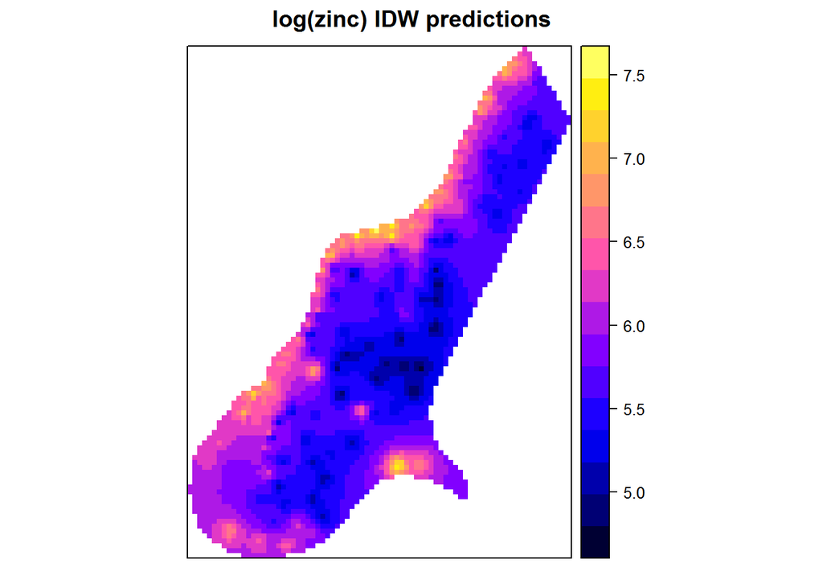

```r
spplot(logzinc.idw,"var1.pred", main = "log(zinc) IDW predictions")
```

Plot the histogram of the predicted values.

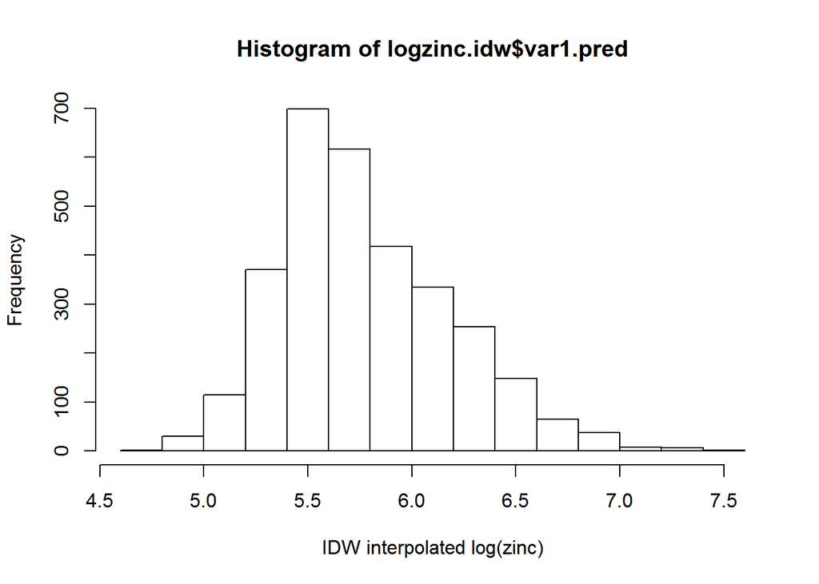

```r
hist(logzinc.idw$var1.pred, xlab="IDW interpolated log(zinc)")
```

For comparison, plot the histogram of the back-transformed predicted values. Think about the reason, why this is important.

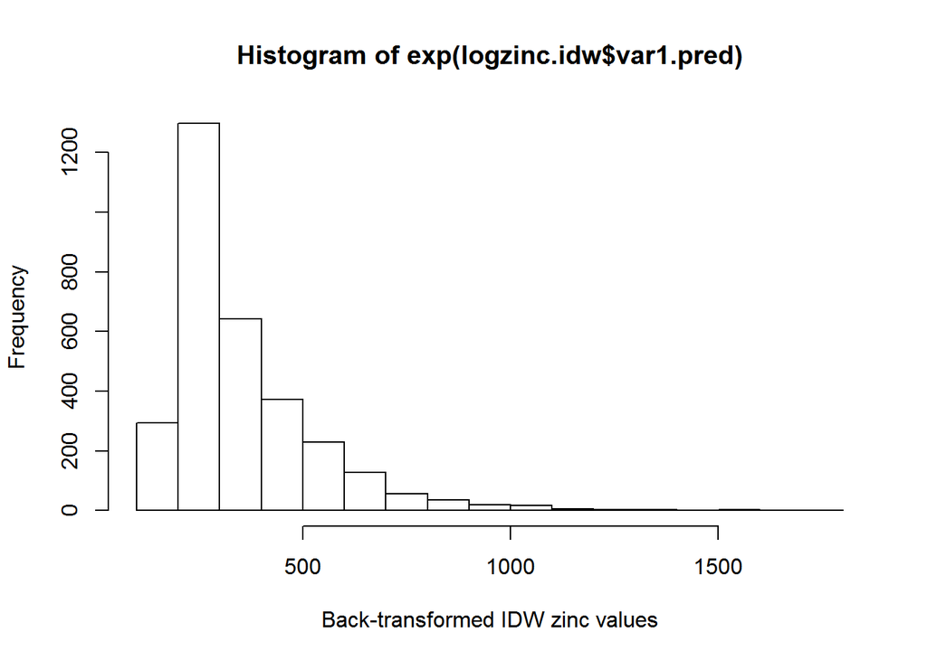

```r
hist(exp(logzinc.idw$var1.pred), xlab="Back-transformed IDW zinc values")
```

### Task

The next step shows the back-transformation of the lognormally transformed predicted values. **Question: Is the use of the exponential function a feasible way to back-transform the lognormally transfromed predicted values or is something missing?**

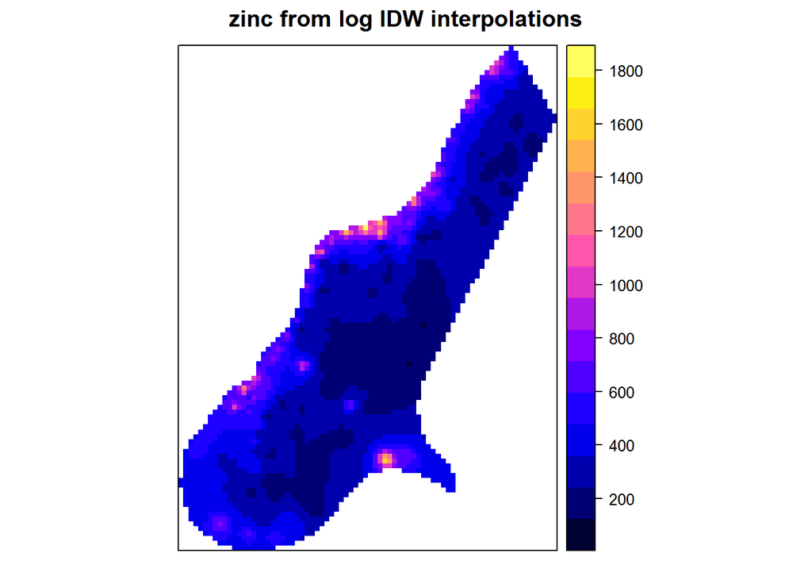

```r
zincfromlog.idw <- logzinc.idw
zincfromlog.idw$var1.pred = exp(logzinc.idw$var1.pred)
spplot(zincfromlog.idw,"var1.pred", main = "zinc from log IDW interpolations")
```

Compare with IDW of zinc concentrations

```r
zinc.idw = idw(zinc~1, meuse, meuse.grid)
```

```
## [inverse distance weighted interpolation]
```

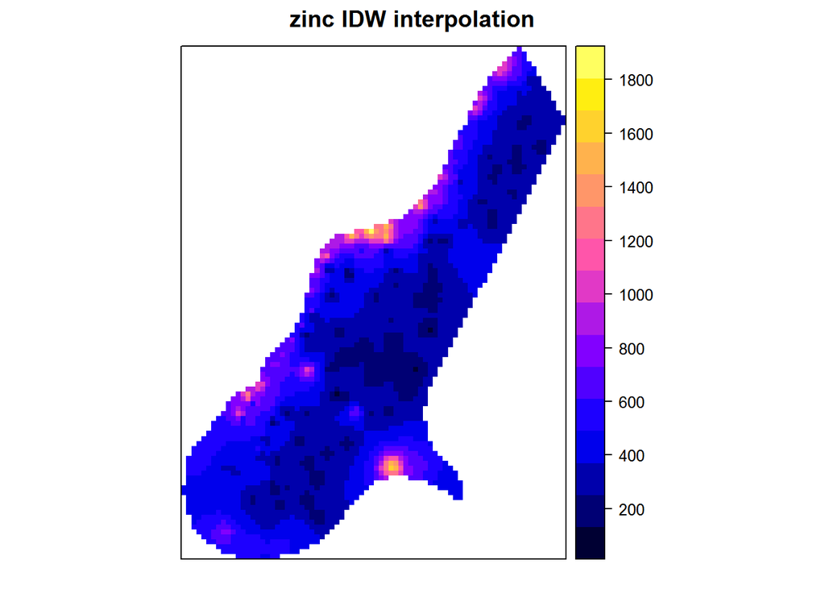

```r
spplot(zinc.idw,"var1.pred", main = "zinc IDW interpolation")
```

Compare again using spplot

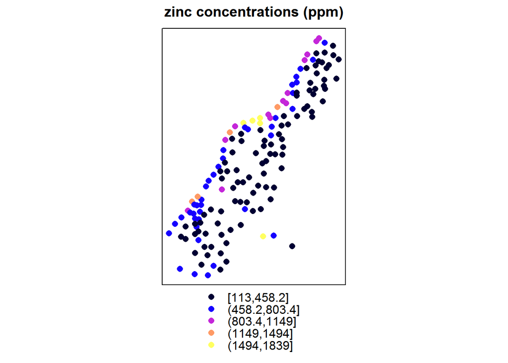

```r
spplot(meuse,zcol="zinc", main = "zinc concentrations (ppm)")
```

Commonly, the inverse distance weighting power is 2, which means that the distance is squared. By setting the idp parameter manually, you can modify the IDW distance function.

```r
logzinc.idw1 = idw(log(zinc)~1, meuse, meuse.grid, idp = 1)
```

```
## [inverse distance weighted interpolation]
```

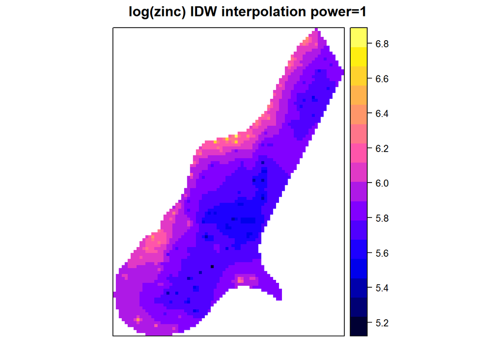

```r
## idp = 2 or idp = 3 -> power parameter for distance
spplot(logzinc.idw1,"var1.pred", main = "log(zinc) IDW interpolation power=1")
```

Compare histograms of predicted values

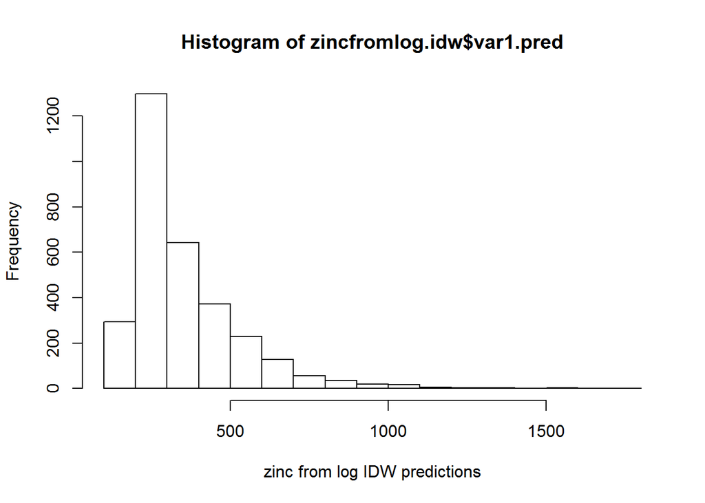

```r
hist(zincfromlog.idw$var1.pred, xlab="zinc from log IDW predictions")
```

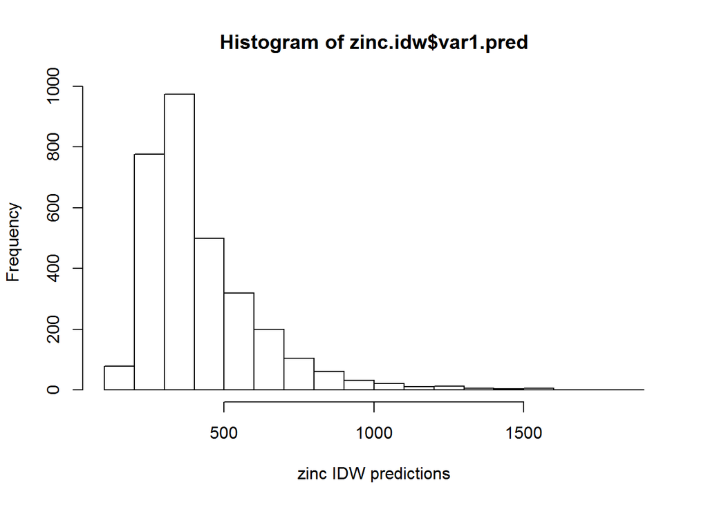

```r
hist(zinc.idw$var1.pred, xlab="zinc IDW predictions")
```

Calculate the variances of the predicted data sets

```r
c(var(zincfromlog.idw$var1.pred),var(zinc.idw$var1.pred))
```

[output not shown]

IDW cross-validation

```r
# create an IDW object in gstat
logzincIDW1.obj <- gstat(id="logzincIDW1.obj", formula = log(zinc) ~ 1, data = meuse,
      nmax=12, set=list(idp=1)) # idp is the power exponent
```

Perform cross-valiation and determine the RMSE

```r
logzincIDW1.cv <- gstat.cv(logzincIDW1.obj, debug.level=0, random=FALSE)
str(logzincIDW1.cv) # list contents
```

```
## Formal class 'SpatialPointsDataFrame' [package "sp"] with 5 slots
##   ..@ data       :'data.frame':  155 obs. of  6 variables:
##   .. ..$ logzincIDW1.obj.pred: num [1:155] 6.37 6.33 6.15 6 5.78 ...
##   .. ..$ logzincIDW1.obj.var : num [1:155] NA NA NA NA NA NA NA NA NA NA ...
##   .. ..$ observed            : num [1:155] 6.93 7.04 6.46 5.55 5.59 ...
##   .. ..$ residual            : num [1:155] 0.564 0.711 0.309 -0.452 -0.188 ...
##   .. ..$ zscore              : num [1:155] NA NA NA NA NA NA NA NA NA NA ...
##   .. ..$ fold                : int [1:155] 1 2 3 4 5 6 7 8 9 10 ...
##   ..@ coords.nrs : num(0)
##   ..@ coords     : num [1:155, 1:2] 181072 181025 181165 181298 181307 ...
##   .. ..- attr(*, "dimnames")=List of 2
##   .. .. ..$ : NULL
##   .. .. ..$ : chr [1:2] "x" "y"
##   ..@ bbox       : num [1:2, 1:2] 178605 329714 181390 333611
##   .. ..- attr(*, "dimnames")=List of 2
##   .. .. ..$ : chr [1:2] "x" "y"
##   .. .. ..$ : chr [1:2] "min" "max"
##   ..@ proj4string:Formal class 'CRS' [package "sp"] with 1 slot
##   .. .. ..@ projargs: chr NA
```

```r
rmse.idp1 <- sqrt(mean(logzincIDW1.cv$residual^2)) # RMS prediction error
```

Repeat for idp=2 by first creating an IDW object, performing the cross-validation, and determining the RMSE

```r
logzincIDW2.obj <- gstat(id="logzincIDW2.obj", formula = log(zinc) ~ 1, data = meuse,
      nmax=12, set=list(idp=2)) # idp is the power exponent
logzincIDW2.cv <- gstat.cv(logzincIDW2.obj, debug.level=0, random=FALSE)
rmse.idp2 <- sqrt(mean(logzincIDW2.cv$residual^2)) # RMS prediction error
c(rmse.idp1, rmse.idp2)
```

```
## [1] 0.4839870 0.4567004
```

IDW interpolation with local neighborhoods

```r
logzinc.idw = idw(log(zinc)~1, meuse, meuse.grid)
```

```
## [inverse distance weighted interpolation]
```

```r
logzinc.idw.loc = idw(log(zinc)~1, meuse, meuse.grid, nmax = 16, nmin = 4, maxdist = 500)
```

```
## [inverse distance weighted interpolation]
```

Plot the interpolated surfaces

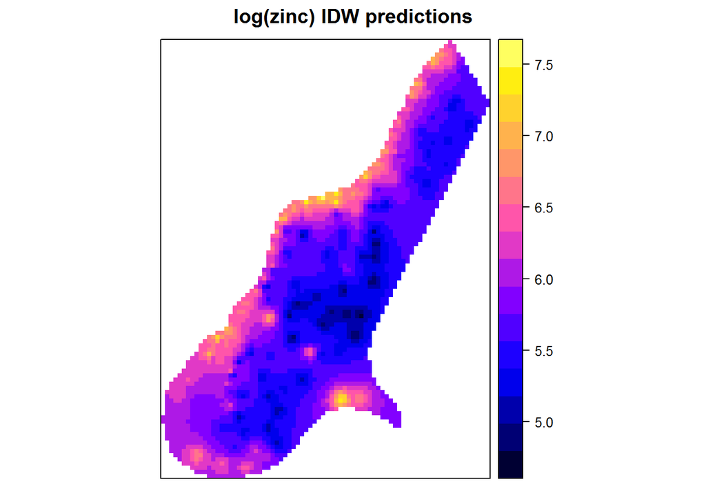

```r
spplot(logzinc.idw,"var1.pred", main = "log(zinc) IDW predictions")
```

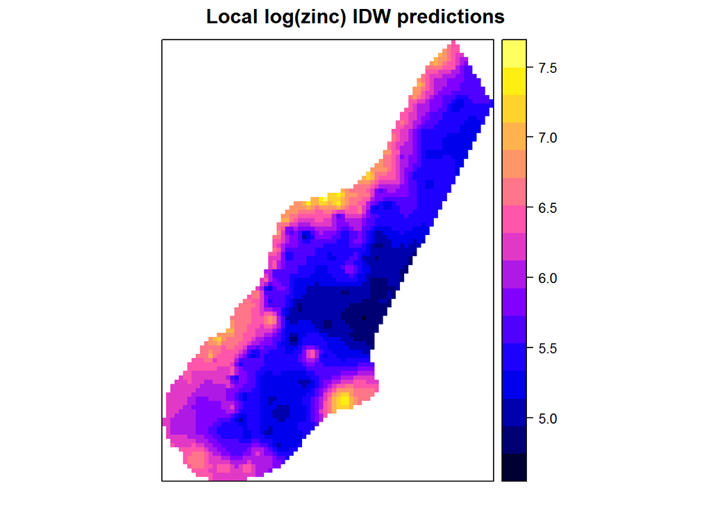

```r
spplot(logzinc.idw.loc,"var1.pred", main = "Local log(zinc) IDW predictions")
```

# Kriging: Introduction

Kriging is an umbrella term encompassing a family of stochastic spatial interpolation and prediction algorithms. In its simplest form, Simple Kriging provides the Best Linear Unbiased Predictor (BLUP) of the unknown attribute values at a set of prediction locations (in a Gaussian context).

The basic steps in Kriging are:

1. Estimate the sample semivariogram, which provides average dissimilarity between sample data pairs within pre-defined distance classes or bands, termed lags
2. Model the sample semivariogram with a continuous function of distance
3. Use that semivariogram model in Kriging routines to furnish the $N$ weights at each interpolation location
4. Compute the corresponding interpolated value $\hat{z}_0$, PLUS a measure of uncertainty, termed prediction error variance, $\hat{\sigma}_0^2$ associated with that value.

As with IDW, one can perform global (involving all sample data) or local (involving sample data within a local neighborhood around ${\bf u}_0$) interpolation.

Similar to IDW, Kriging considers the distance between sample data locations and the prediction location to determine the Kriging weights. Unlike IDW, however, Kriging accounts for the smoothness (or spatial dissimilarity) of the particular phenomenon under study, and for the redundancy between the data sample locations.

# Semivariogram Estimation and Modeling

Semivariogram cloud

```r
lzn.vgmcloud = variogram(log(zinc)~1, meuse, cloud = T)
str(lzn.vgmcloud)
```

```
## Classes 'variogramCloud' and 'data.frame':   6883 obs. of  6 variables:
##  $ np     : num  1 2 65538 3 65539 ...
##  $ dist   : num  70.8 118.8 141.6 259.2 282.9 ...
##  $ gamma  : num  0.00607 0.10953 0.16715 0.95281 1.11092 ...
##  $ dir.hor: num  0 0 0 0 0 0 0 0 0 0 ...
##  $ dir.ver: num  0 0 0 0 0 0 0 0 0 0 ...
##  $ id     : Factor w/ 1 level "var1": 1 1 1 1 1 1 1 1 1 1 ...
##  - attr(*, "direct")='data.frame':   1 obs. of  2 variables:
##   ..$ id       : Factor w/ 1 level "var1": 1
##   ..$ is.direct: logi TRUE
##  - attr(*, ".BigInt")= num 65536
##  - attr(*, "what")= chr "semivariance"
```

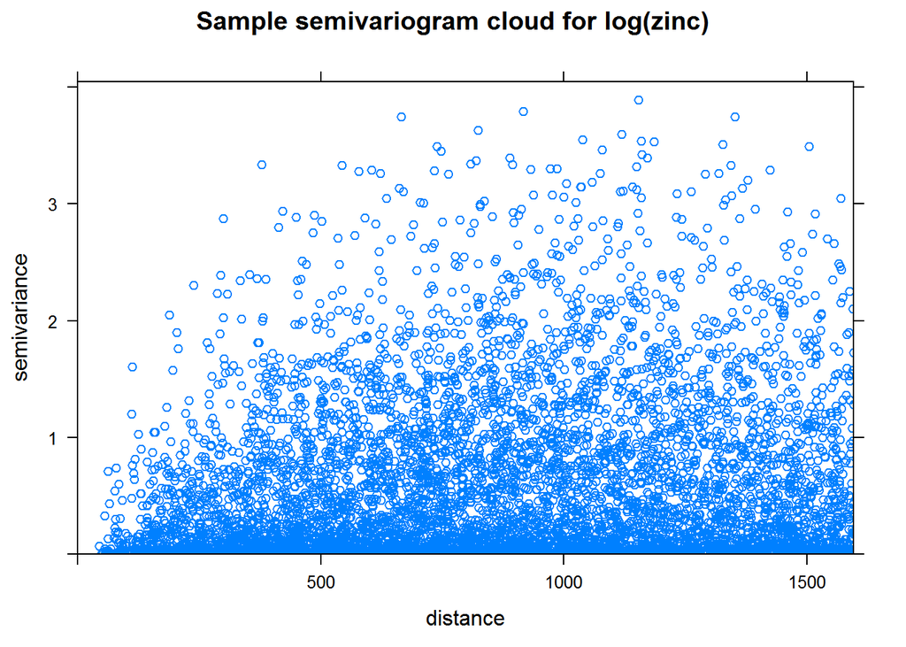

```r
plot(lzn.vgmcloud, main='Sample semivariogram cloud for log(zinc)')
```

Sample or empirical semivariogram

```r
lzn.vgm = variogram(log(zinc)~1, meuse)
# ~1 means constant trend for log(zinc)
lzn.vgm
```

```
##     np       dist     gamma dir.hor dir.ver   id
## 1   57   79.29244 0.1234479       0       0 var1
## 2  299  163.97367 0.2162185       0       0 var1
## 3  419  267.36483 0.3027859       0       0 var1
## 4  457  372.73542 0.4121448       0       0 var1
## 5  547  478.47670 0.4634128       0       0 var1
## 6  533  585.34058 0.5646933       0       0 var1
## 7  574  693.14526 0.5689683       0       0 var1
## 8  564  796.18365 0.6186769       0       0 var1
## 9  589  903.14650 0.6471479       0       0 var1
## 10 543 1011.29177 0.6915705       0       0 var1
## 11 500 1117.86235 0.7033984       0       0 var1
## 12 477 1221.32810 0.6038770       0       0 var1
## 13 452 1329.16407 0.6517158       0       0 var1
## 14 457 1437.25620 0.5665318       0       0 var1
## 15 415 1543.20248 0.5748227       0       0 var1
```

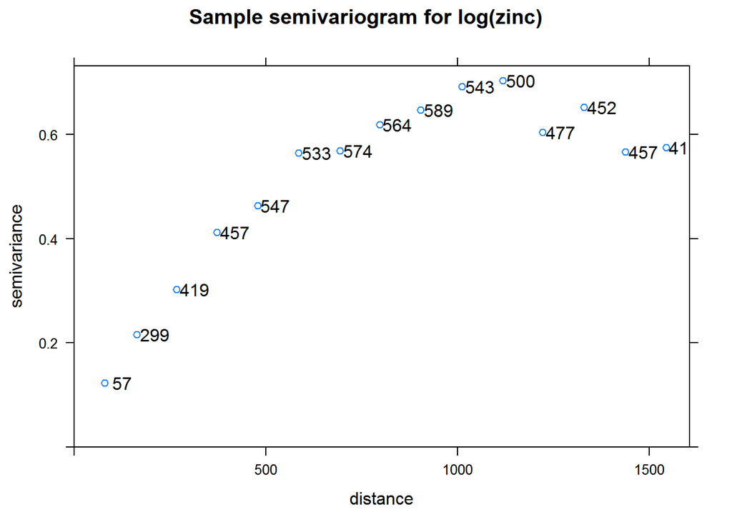

```r
plot(lzn.vgm,plot.numbers = T,
     main='Sample semivariogram for log(zinc)')
```

Try different distance classes

```r
lzn.vgm2 = variogram(log(zinc)~1, meuse, width = 75, cutoff = 1500)
str(lzn.vgm2)
```

```
## Classes 'gstatVariogram' and 'data.frame':   20 obs. of  6 variables:
##  $ np     : num  20 146 236 294 323 348 371 366 393 421 ...
##  $ dist   : num  61.1 121 189.7 263.5 339.5 ...
##  $ gamma  : num  0.103 0.153 0.248 0.311 0.339 ...
##  $ dir.hor: num  0 0 0 0 0 0 0 0 0 0 ...
##  $ dir.ver: num  0 0 0 0 0 0 0 0 0 0 ...
##  $ id     : Factor w/ 1 level "var1": 1 1 1 1 1 1 1 1 1 1 ...
##  - attr(*, "direct")='data.frame':   1 obs. of  2 variables:
##   ..$ id       : Factor w/ 1 level "var1": 1
##   ..$ is.direct: logi TRUE
##  - attr(*, "boundaries")= num  0 75 150 225 300 375 450 525 600 675 ...
##  - attr(*, "pseudo")= num 0
##  - attr(*, "what")= chr "semivariance"
```

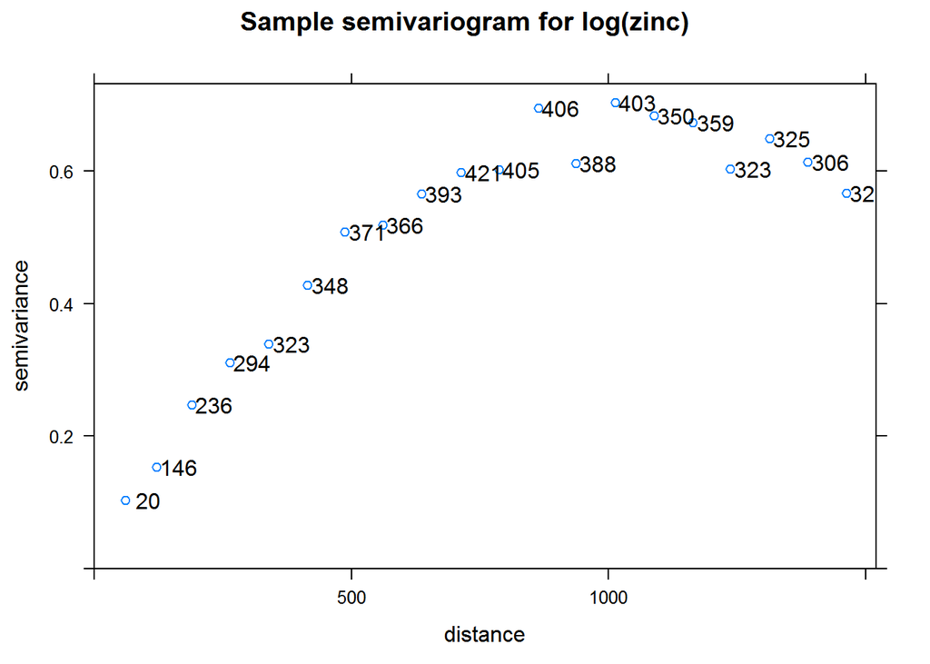

```r
plot(lzn.vgm2,plot.numbers = T,
     main='Sample semivariogram for log(zinc)')
```

Model semivariogram

Spherical model with range 900 and partial sill = 0.7 PLUS nugget effect with partial sill = 0.1

```r
model = vgm(0.7, "Sph", 900, 0.1)
```

Evaluate model

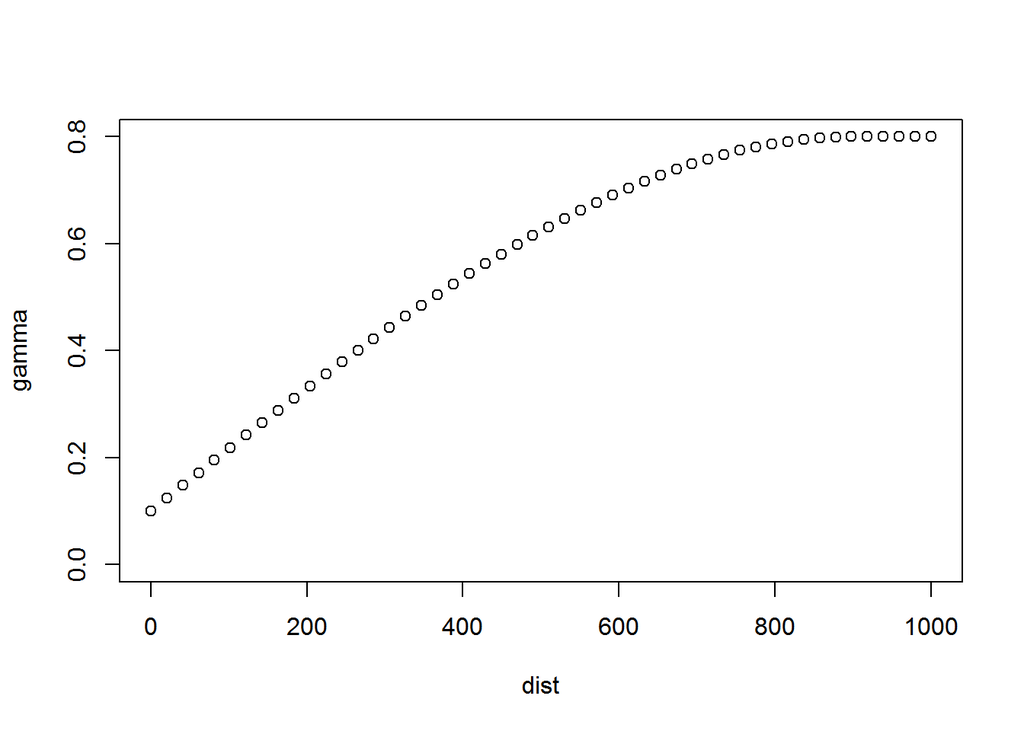

```r
modelEval = variogramLine(model,1000,50,0.1)
# start from 0.1, go up to 1000, and put 50 distance
# values in that [0.1, 1000] interval
plot(modelEval,ylim=c(0,0.8))
```

Fitting model semivariogram to empirical semivariogram

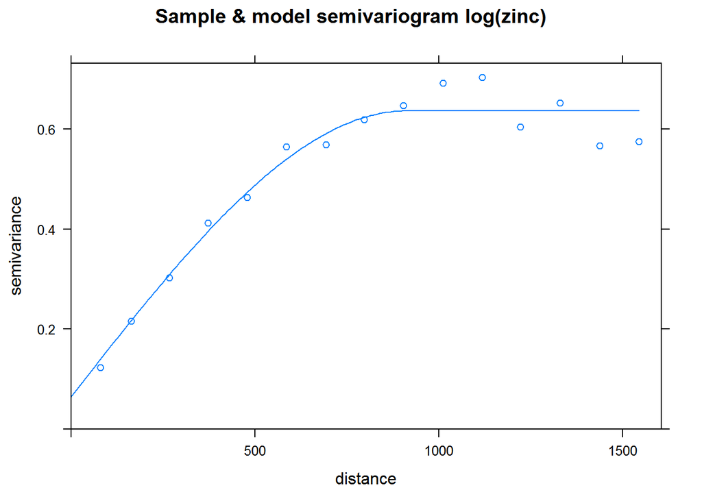

```r
lzn.vgm.fit = fit.variogram(lzn.vgm,model,fit.method=1)
plot(lzn.vgm,lzn.vgm.fit,main='Sample & model semivariogram log(zinc)')
```

```r
str(lzn.vgm.fit)
```

```
## Classes 'variogramModel' and 'data.frame':   2 obs. of  9 variables:
##  $ model: Factor w/ 20 levels "Nug","Exp","Sph",..: 1 3
##  $ psill: num  0.0651 0.5711
##  $ range: num  0 911
##  $ kappa: num  0 0.5
##  $ ang1 : num  0 0
##  $ ang2 : num  0 0
##  $ ang3 : num  0 0
##  $ anis1: num  1 1
##  $ anis2: num  1 1
##  - attr(*, "singular")= logi FALSE
##  - attr(*, "SSErr")= num 9.22
##  - attr(*, "call")= language fit.variogram(object = lzn.vgm, model = model, fit.method = 1)
```

```r
sse1 <- attr(lzn.vgm.fit,"SSErr")
```